# Clustering Shakespeare Authorship

Ben Warren

7/10/2022

The poems in *The Passionate Pilgrim*, a 1599 poetry anthology, were originally attributed to William Shakespeare. Since that time, however, some have been found to be written by other prominent poets of the time, such as Christopher Marlowe, Richard Barnfield, and Bartholomew Griffin. This analysis seeks to use 2 different clustering techniques (hierarchical, k-means) to classify the remaining poems with unknown authorship into categories with distinct stylistic fingerprints, which I will then correlate with different authors.

There are 11 unattributed poems to work with, and as many as 8 of them (Elliot and Valenza, 1991) have been stylistically linked to Shakespeare.

I previously carried out an analysis, along with classmates at Dickinson College that attributed 3 additional poems to Shakespeare, 4 to Marlowe, 2 to Griffin, and 2 to Barnfield.

Unknown author data set summary:

```
##     word_len       sent_comp        line_len
##  Min.   :4.135   Min.   :4.980   Min.   : 7.400
##  1st Qu.:4.314   1st Qu.:7.905   1st Qu.: 9.336
##  Median :4.363   Median :8.357   Median :10.750
##  Mean   :4.439   Mean   :7.999   Mean   :11.902
##  3rd Qu.:4.525   3rd Qu.:8.625   3rd Qu.:13.500
##  Max.   :5.095   Max.   :9.125   Max.   :19.500
```

Distributions:

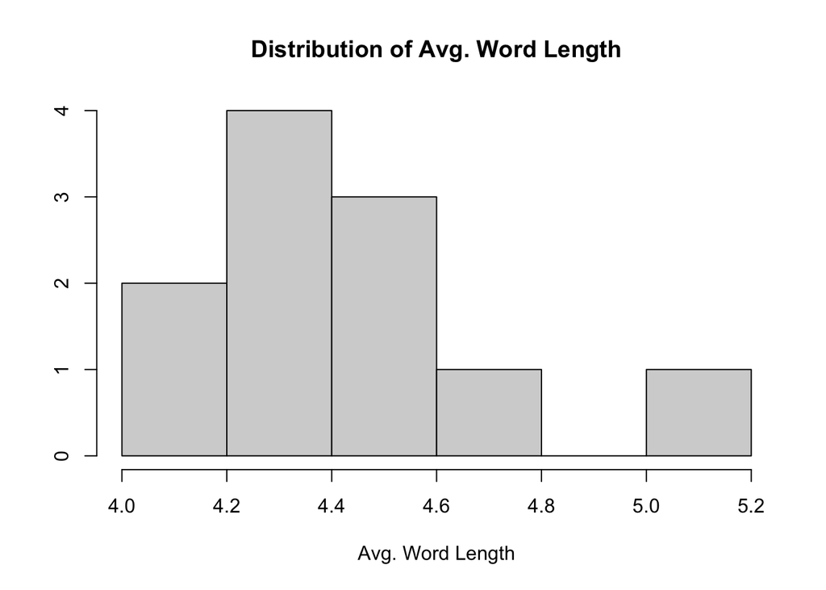

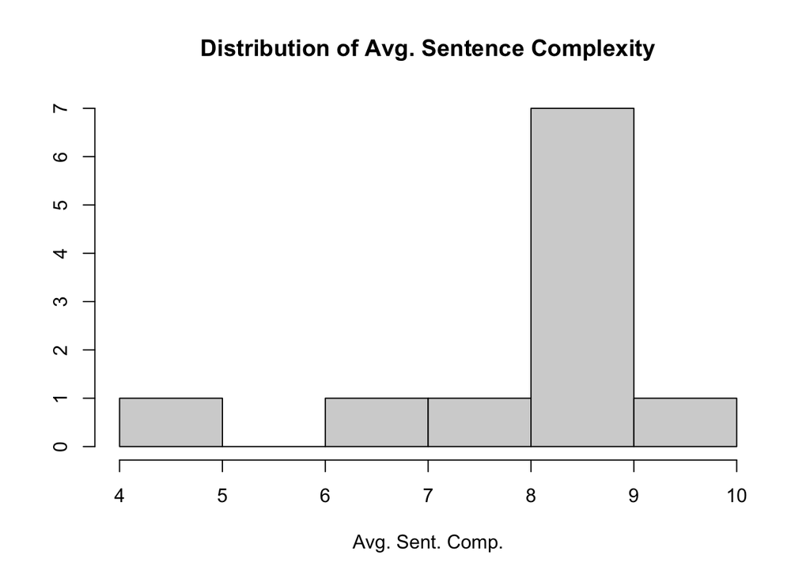

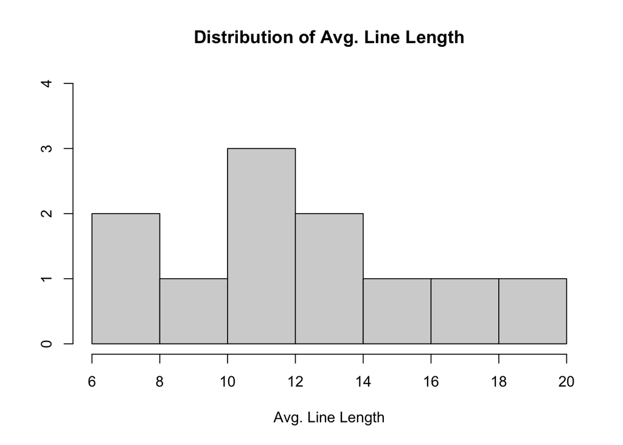

Standardized values

```
##     word_len         sent_comp           line_len
##  Min.   :-1.1405   Min.   :-2.56853   Min.   :-1.1651
##  1st Qu.:-0.4701   1st Qu.:-0.07991   1st Qu.:-0.6639
##  Median :-0.2863   Median : 0.30495   Median :-0.2981
##  Mean   : 0.0000   Mean   : 0.00000   Mean   : 0.0000
##  3rd Qu.: 0.3213   3rd Qu.: 0.53283   3rd Qu.: 0.4137
##  Max.   : 2.4625   Max.   : 0.95821   Max.   : 1.9665
```

**Hierarchical Clustering:**

This technique iterates through the relationships between points in the data set and compares the similarity of their characteristics to form a hierarchy demonstrating the relative distance and proximity of each data point. For example, in this analysis, poem #10 is very similar to poem #6, while poem #13 is somewhat unique, warranting its own split branch from the rest of the data set.

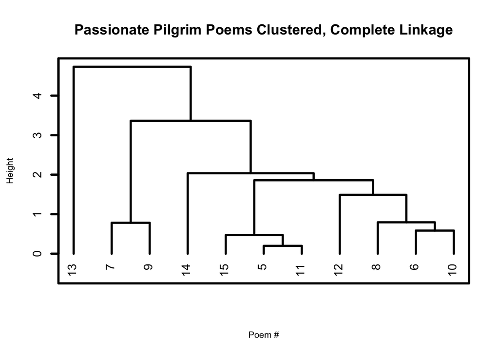

Clusters created:

Cluster 1: Poem #13

Cluster 2: Poems #7, #9

Cluster 3: Poem #14

Cluster 4: Poems #15, 5, 11

Cluster 5: Poems #12, 8, 6, 10

Notes:

- These numbers are not the order they are written in *The Passionate Pilgrim*, but rather the order they appear in the dataframe we use here.
- This conclusion relies on a cut-off height of ~1.75 - with a greater height, clusters 4 and 5, or 3, 4, and 5 could be combined.

Summary statistics on each cluster (with >1 item) can be seen here:

```
## [1] "Cluster #2"
```

```
##     word_len       sent_comp        line_len
##  Min.   :4.576   Min.   :7.667   Min.   :17.00
##  1st Qu.:4.588   1st Qu.:7.786   1st Qu.:17.62
##  Median :4.599   Median :7.905   Median :18.25
##  Mean   :4.599   Mean   :7.905   Mean   :18.25
##  3rd Qu.:4.610   3rd Qu.:8.024   3rd Qu.:18.88
##  Max.   :4.621   Max.   :8.143   Max.   :19.50
```

```
## [1] "Cluster #4"
```

```
##     word_len       sent_comp        line_len
##  Min.   :4.336   Min.   :8.667   Min.   :7.400
##  1st Qu.:4.343   1st Qu.:8.778   1st Qu.:7.414
##  Median :4.351   Median :8.889   Median :7.429
##  Mean   :4.350   Mean   :8.894   Mean   :7.743
##  3rd Qu.:4.357   3rd Qu.:9.007   3rd Qu.:7.914
##  Max.   :4.363   Max.   :9.125   Max.   :8.400
```

```
## [1] "Cluster #5"
```

```
##     word_len       sent_comp        line_len
##  Min.   :4.135   Min.   :8.167   Min.   :10.75
##  1st Qu.:4.141   1st Qu.:8.310   1st Qu.:12.19
##  Median :4.218   Median :8.448   Median :12.67
##  Mean   :4.254   Mean   :8.411   Mean   :12.60
##  3rd Qu.:4.331   3rd Qu.:8.550   3rd Qu.:13.08
##  Max.   :4.446   Max.   :8.583   Max.   :14.33
```

Comparing the clusters:

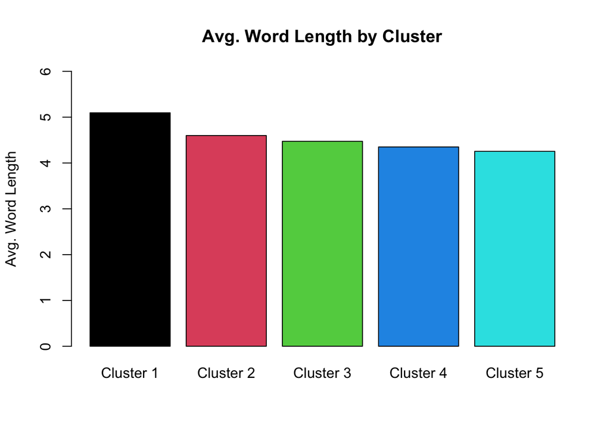

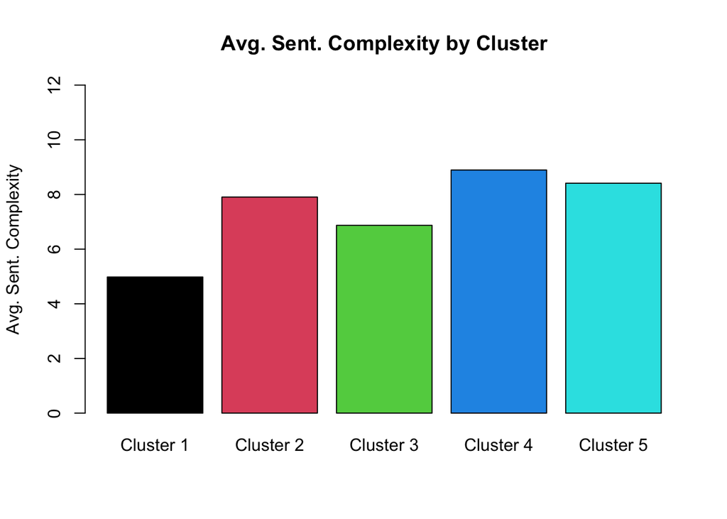

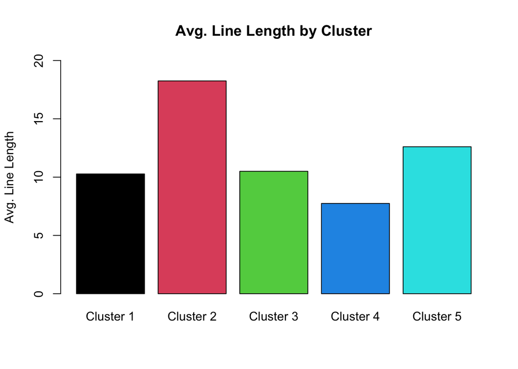

**K-means clustering technique**

Find the optimal number of clusters by identifying the value of k for which the within-group sum of squares (measure of variance within clusters) decreases the most.

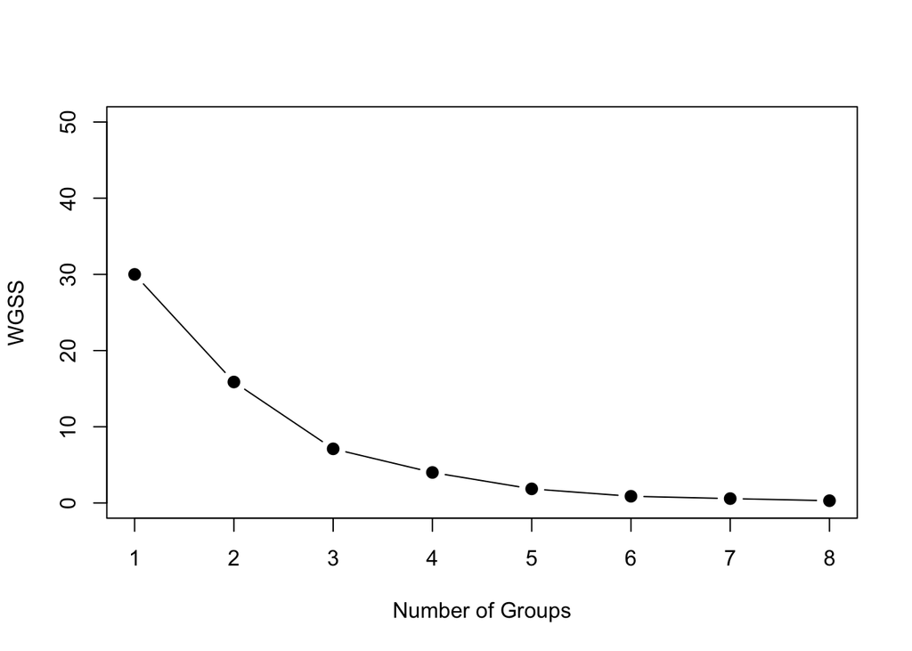

3 clusters seems appropriate - we will run the k-means algorithm for 3 and 4 clusters.

```
##    word_len sent_comp  line_len km_3 km_4
## 1  5.095238  4.979592 10.272727    1    1
## 2  4.576471  7.666667 17.000000    2    4
## 3  4.621359  8.142857 19.500000    2    4
## 4  4.445545  8.538462 14.333333    2    2
## 5  4.350515  8.666667  7.400000    3    3
## 6  4.142857  8.166667 12.666667    3    2
## 7  4.135417  8.583333 10.750000    3    2
## 8  4.292453  8.357143 12.666667    3    2
## 9  4.335570  8.888889  7.428571    3    3
## 10 4.473214  6.870370 10.500000    3    2
## 11 4.362963  9.125000  8.400000    3    3
```

**Summarizing Clusters**

```
## # A tibble: 3 × 4
##    km_3 word_len sent_comp line_len
##   <int>    <dbl>     <dbl>    <dbl>
## 1     1     5.10      4.98    10.3
## 2     2     4.55      8.12    16.9
## 3     3     4.30      8.38     9.97
```

```
## # A tibble: 4 × 4
##    km_4 word_len sent_comp line_len
##   <int>    <dbl>     <dbl>    <dbl>
## 1     1     5.10      4.98    10.3
## 2     2     4.30      8.10    12.2
## 3     3     4.35      8.89     7.74
## 4     4     4.60      7.90    18.2
```

**Boxplot visualization of cluster statistics**

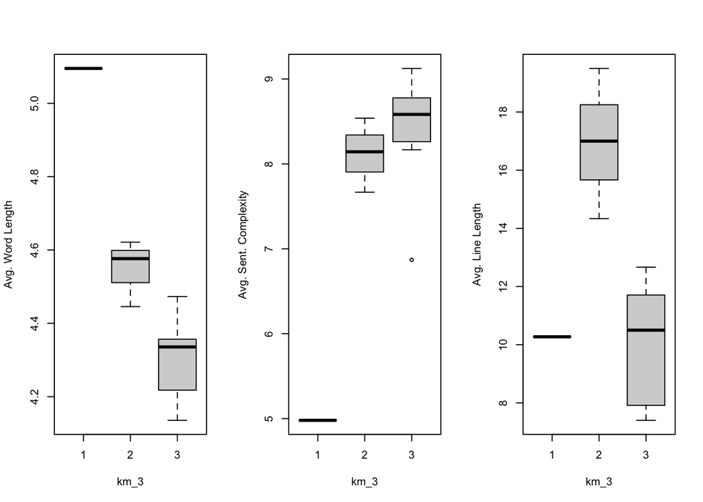

As you can see, each cluster seems to have its own unique characteristics. Cluster 1 has a high average word length and a low average sentence complexity. Cluster 2 has pretty moderate avg. word length and a fairly high complexity. And cluster 3 has a low avg. word length and a high avg. sentence complexity. (An interesting note here is that earlier investigation found an inverse correlation between word length and sentence complexity, so the fact that the cluster characteristics belie a similar relationship is unsurprising).

Similar analysis for 4 clusters instead:

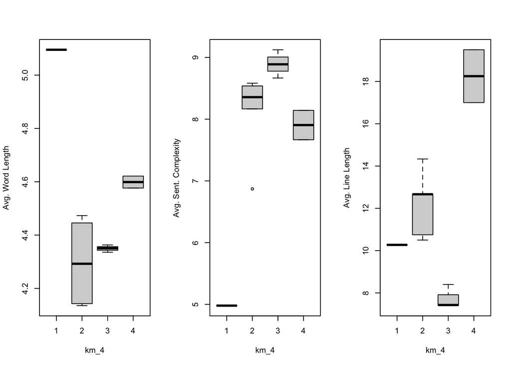

**Compare Clusters to Author Fingerprints**

Shakespeare fingerprint:

- Average word length: 4.549430
- Average sentence complexity: 7.972973
- Average line length: 8.217391

Marlowe fingerprint:

- Average word length: 4.846154
- Average sentence complexity: 6.000000
- Average line length: 7.750000

Griffin fingerprint:

- Average word length: 4.061404
- Average sentence complexity: 8.928571
- Average line length: 15.000000

- Average word length: 4.872679
- Average sentence complexity: 6.194444
- Average line length: 10.312500

**Matched author fingerprints with mean cluster fingerprints using lowest geometric mean in Python**

Results:

These findings imply that Cluster 1 (Poem X) most closely matches Barnfield’s writing style, Clusters 2 (Poems XIV, VI, VII, IX, XVIII) and 4 (Poems XII and XIII) most closely match Shakespeare (with the latter possessing a higher certainty, and Cluster 3 (Poems IV, XVII, and XV) most closely match Marlowe’s style.

When we compare these findings with the analysis of Pranav, Sid, and myself from fall 2021: - We agreed on VI, IX, and XV - We disagreed on XIV, VII, X, IV, XVII, XII, XIII, and XVII

If I had to point to any of the unattributed poems in *The Passionate Pilgrim* as most likely written by Shakespeare, I would choose Poems VI and IX, which this analysis, my earlier analysis (with Lamsdal and Mishra), and Elliot and Valenza’s analysis in 1991 agree to be most likely written by Shakespeare.

**Poem VI** (Project Gutenberg)

Scarce had the sun dried up the dewy morn,

And scarce the herd gone to the hedge for shade,

When Cytherea, all in love forlorn,

A longing tarriance for Adonis made

Under an osier growing by a brook,

A brook where Adon used to cool his spleen:

Hot was the day; she hotter that did look

For his approach, that often there had been.

Anon he comes, and throws his mantle by,

And stood stark naked on the brook’s green brim:

The sun look’d on the world with glorious eye,

Yet not so wistly as this queen on him.

He, spying her, bounced in, whereas he stood:

‘O Jove,’ quoth she, ‘why was not I a flood!’

**Poem IX** (Project Gutenberg)

Fair was the morn when the fair queen of love,

* * * * * *

Paler for sorrow than her milk-white dove,

For Adon’s sake, a youngster proud and wild;

Her stand she takes upon a steep-up hill:

Anon Adonis comes with horn and hounds;

She, silly queen, with more than love’s good will,

Forbade the boy he should not pass those grounds:

‘Once,’ quoth she, ’did I see a fair sweet youth

Here in these brakes deep-wounded with a boar,

Deep in the thigh, a spectacle of ruth!

See, in my thigh,’ quoth she, ’here was the sore.

She showed hers: he saw more wounds than one,

And blushing fled, and left her all alone.

If indeed, these poems were written by Shakespeare, they are not his best work. And yet, does the former not closely share the meter (with its 10-syllable length and emphasis pattern) and some subject matter (Adonis is, of course, featured in the early Shakespearean poem *Venus and Adonis*) with The Bard’s work? Perhaps I trust too much in the algorithm and am reaching here.

Irrespective of accuracy, this is nonetheless an interesting investigation of the breadth of possible computational techniques to be used in stylistic and literary analysis.